# Joint Headline HICP — 4-component Bayesian VAR with SV and model-based outliers

## 8. Posterior coefficients

Headline joint BVAR(12) posterior coefficients

|  | prior_mean | prior_sd | posterior_mean | posterior_median | posterior_sd | q05 | q16 | q84 | q95 | ESS |
| --- | --- | --- | --- | --- | --- | --- | --- | --- | --- | --- |
| state__hicp_energy: const | 0.00 | 0.17 | 1.11 × 10⁻³ | 1.11 × 10⁻³ | 1.05 × 10⁻³ | -6.23 × 10⁻⁴ | 6.64 × 10⁻⁵ | 2.16 × 10⁻³ | 2.88 × 10⁻³ | 1645.95 |
| state__hicp_energy: state__hicp_energy L1 | 0.00 | 0.20 | 0.37 | 0.37 | 0.05 | 0.28 | 0.32 | 0.43 | 0.46 | 2265.91 |
| state__hicp_energy: state__hicp_food L1 | 0.00 | 0.55 | 0.26 | 0.26 | 0.24 | -0.13 | 0.03 | 0.50 | 0.66 | 1694.86 |
| state__hicp_energy: state__hicp_neig L1 | 0.00 | 0.11 | 0.03 | 0.03 | 0.05 | -0.05 | -0.02 | 0.09 | 0.12 | 1902.67 |
| state__hicp_energy: state__hicp_services L1 | 0.00 | 0.32 | 0.26 | 0.26 | 0.14 | 0.04 | 0.12 | 0.39 | 0.48 | 1480.04 |
| state__hicp_energy: state__hicp_energy L2 | 0.00 | 0.10 | -0.13 | -0.13 | 0.05 | -0.22 | -0.19 | -0.08 | -0.05 | 671.02 |
| state__hicp_energy: state__hicp_food L2 | 0.00 | 0.28 | 0.10 | 0.10 | 0.19 | -0.21 | -0.09 | 0.29 | 0.40 | 1983.42 |
| state__hicp_energy: state__hicp_neig L2 | 0.00 | 0.06 | -0.04 | -0.04 | 0.04 | -0.11 | -0.08 | -3.53 × 10⁻³ | 0.02 | 2212.55 |
| state__hicp_energy: state__hicp_services L2 | 0.00 | 0.16 | -0.07 | -0.07 | 0.11 | -0.25 | -0.18 | 0.04 | 0.12 | 1195.56 |
| state__hicp_energy: state__hicp_energy L3 | 0.00 | 0.07 | -0.01 | -0.01 | 0.04 | -0.08 | -0.06 | 0.03 | 0.06 | 1790.86 |
| state__hicp_energy: state__hicp_food L3 | 0.00 | 0.18 | -0.15 | -0.15 | 0.15 | -0.40 | -0.31 | 1.29 × 10⁻³ | 0.10 | 2281.09 |
| state__hicp_energy: state__hicp_neig L3 | 0.00 | 0.04 | -4.24 × 10⁻³ | -4.27 × 10⁻³ | 0.03 | -0.06 | -0.04 | 0.03 | 0.05 | 2914.98 |
| state__hicp_energy: state__hicp_services L3 | 0.00 | 0.11 | 8.49 × 10⁻³ | 0.01 | 0.09 | -0.14 | -0.08 | 0.10 | 0.15 | 2377.75 |
| state__hicp_energy: state__hicp_energy L4 | 0.00 | 0.05 | -0.01 | -0.01 | 0.04 | -0.07 | -0.05 | 0.03 | 0.05 | 2367.26 |
| state__hicp_energy: state__hicp_food L4 | 0.00 | 0.14 | -0.04 | -0.04 | 0.12 | -0.24 | -0.16 | 0.09 | 0.16 | 2774.64 |
| state__hicp_energy: state__hicp_neig L4 | 0.00 | 0.03 | 0.02 | 0.02 | 0.03 | -0.02 | -4.76 × 10⁻³ | 0.05 | 0.06 | 1706.24 |
| state__hicp_energy: state__hicp_services L4 | 0.00 | 0.08 | -0.06 | -0.06 | 0.07 | -0.17 | -0.13 | 0.02 | 0.06 | 2555.62 |
| state__hicp_energy: state__hicp_energy L5 | 0.00 | 0.04 | 8.49 × 10⁻³ | 8.58 × 10⁻³ | 0.03 | -0.05 | -0.02 | 0.04 | 0.06 | 1683.80 |
| state__hicp_energy: state__hicp_food L5 | 0.00 | 0.11 | -0.06 | -0.06 | 0.10 | -0.23 | -0.16 | 0.04 | 0.11 | 2845.64 |
| state__hicp_energy: state__hicp_neig L5 | 0.00 | 0.02 | 4.56 × 10⁻³ | 4.55 × 10⁻³ | 0.02 | -0.03 | -0.02 | 0.03 | 0.04 | 2723.67 |
| state__hicp_energy: state__hicp_services L5 | 0.00 | 0.06 | -0.02 | -0.02 | 0.06 | -0.11 | -0.08 | 0.04 | 0.08 | 2803.08 |
| state__hicp_energy: state__hicp_energy L6 | 0.00 | 0.03 | 0.01 | 0.01 | 0.03 | -0.04 | -0.02 | 0.04 | 0.06 | 2017.04 |
| state__hicp_energy: state__hicp_food L6 | 0.00 | 0.09 | 2.37 × 10⁻³ | 1.07 × 10⁻³ | 0.08 | -0.14 | -0.08 | 0.09 | 0.14 | 2397.60 |
| state__hicp_energy: state__hicp_neig L6 | 0.00 | 0.02 | -7.79 × 10⁻³ | -7.47 × 10⁻³ | 0.02 | -0.04 | -0.03 | 0.01 | 0.02 | 2694.14 |
| state__hicp_energy: state__hicp_services L6 | 0.00 | 0.05 | 0.02 | 0.02 | 0.05 | -0.06 | -0.03 | 0.07 | 0.11 | 2166.24 |
| state__hicp_energy: state__hicp_energy L7 | 0.00 | 0.03 | 2.82 × 10⁻³ | 2.79 × 10⁻³ | 0.03 | -0.04 | -0.02 | 0.03 | 0.05 | 2749.19 |
| state__hicp_energy: state__hicp_food L7 | 0.00 | 0.08 | -0.04 | -0.04 | 0.08 | -0.16 | -0.11 | 0.04 | 0.09 | 2577.45 |
| state__hicp_energy: state__hicp_neig L7 | 0.00 | 0.02 | -4.79 × 10⁻⁴ | -6.06 × 10⁻⁴ | 0.02 | -0.03 | -0.02 | 0.02 | 0.03 | 3000.00 |
| state__hicp_energy: state__hicp_services L7 | 0.00 | 0.05 | 0.02 | 0.02 | 0.04 | -0.05 | -0.02 | 0.06 | 0.09 | 2832.49 |
| state__hicp_energy: state__hicp_energy L8 | 0.00 | 0.03 | -0.01 | -0.01 | 0.02 | -0.05 | -0.04 | 8.63 × 10⁻³ | 0.02 | 2424.44 |

[output cut: 166 more lines]

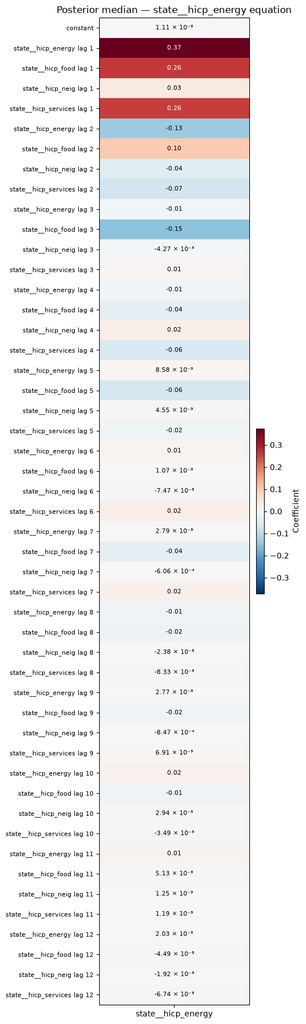

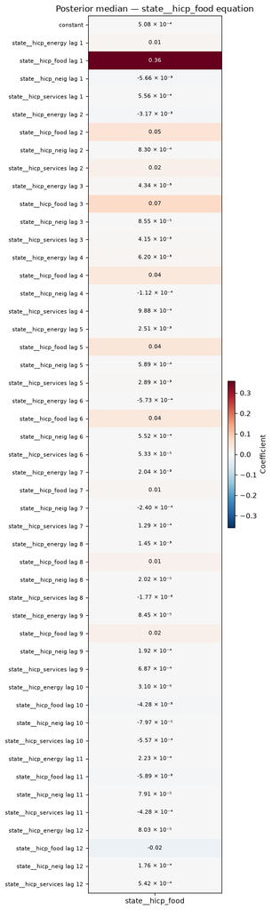

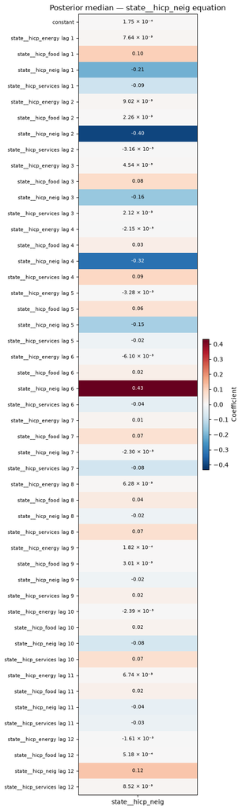

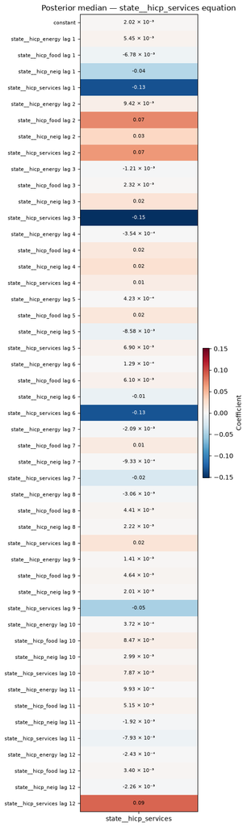

```python
coef = coefficient_posterior_table(result_12)
display(style_numeric_table(coef, caption="Headline joint BVAR(12) posterior coefficients"))

for equation in result_12["variables"]:
    fig = plot_coefficient_heatmap(result_12, equation=equation)
    display(fig)
    plt.close(fig)
```

## 9. Stochastic volatility, outliers and residual diagnostics

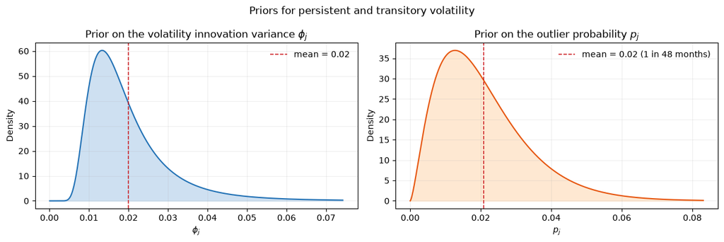

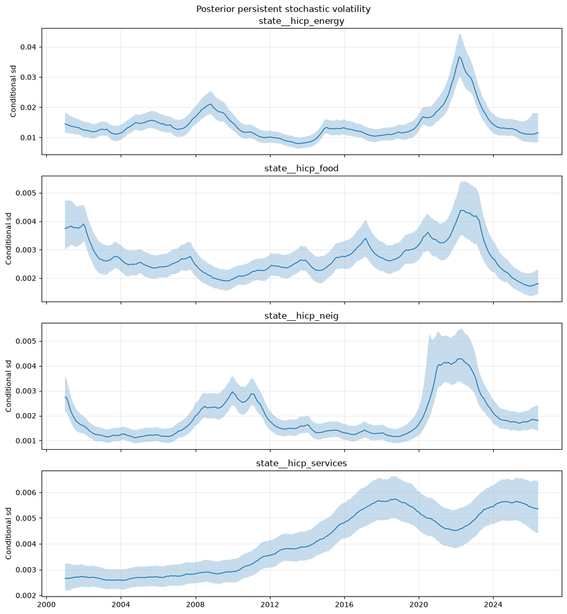

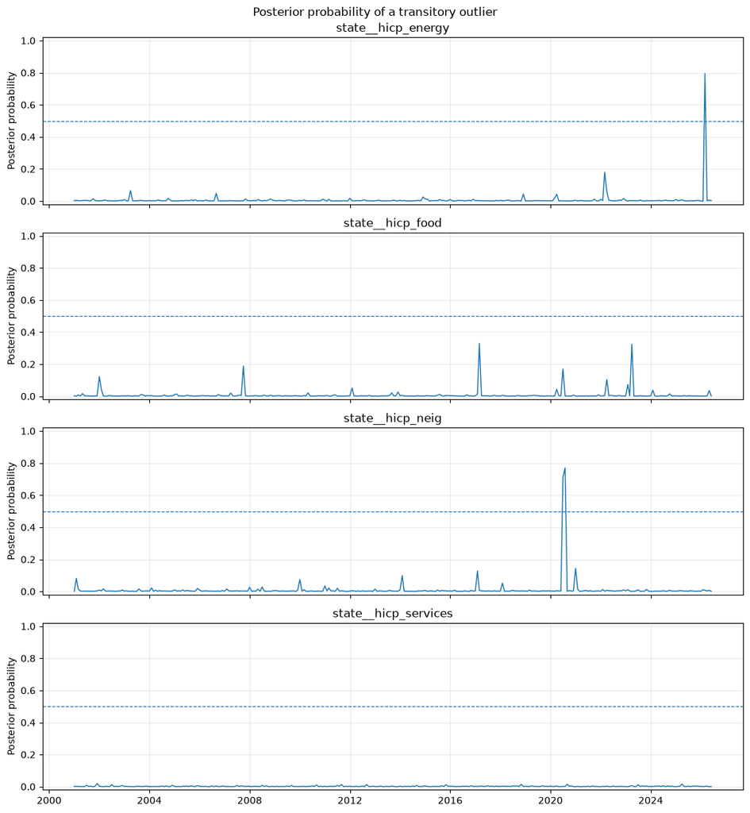

Standardised residual diagnostics

| variable | mean | sd | skewness | excess_kurtosis | acf_1 | maximum_absolute |
| --- | --- | --- | --- | --- | --- | --- |
| state__hicp_energy | 0.01 | 0.96 | -0.12 | -0.09 | 0.04 | 2.89 |
| state__hicp_food | 0.03 | 0.99 | -0.08 | 0.63 | -0.02 | 3.24 |
| state__hicp_neig | 0.04 | 0.92 | -0.16 | -0.04 | -0.04 | 2.58 |
| state__hicp_services | -9.04 × 10⁻³ | 0.96 | -0.04 | -0.24 | -0.02 | 2.24 |

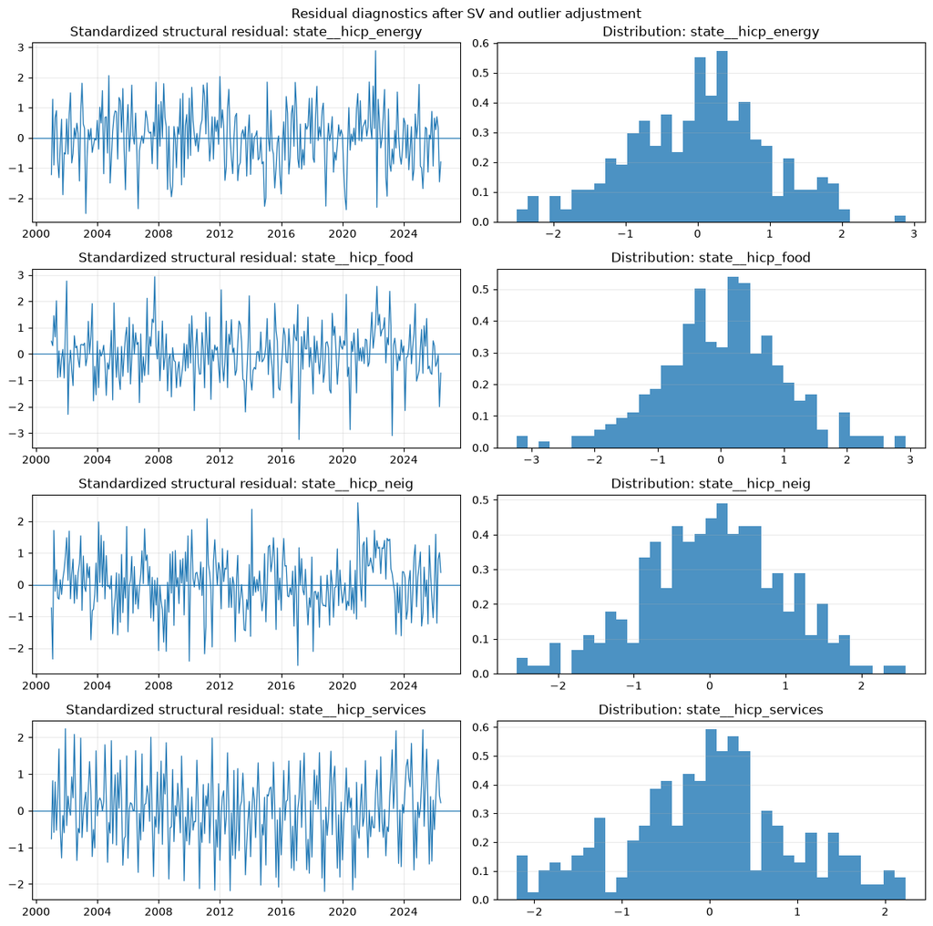

```python
fig = plot_phi_and_outlier_priors(result_12["prior"])
display(fig)
plt.close(fig)

fig = plot_posterior_volatility(result_12, include_outliers=False)
display(fig)
plt.close(fig)

fig = plot_outlier_probabilities(result_12)
display(fig)
plt.close(fig)

residual_diag = residual_diagnostic_table(result_12)
display(style_numeric_table(residual_diag, caption="Standardised residual diagnostics"))

fig = plot_standardized_residuals(result_12)
display(fig)
plt.close(fig)
```

## 10. Joint component forecast

```python
component_forecast = forecast_headline_joint_bvar(
    result_12,
    native_levels=native_levels,
    H=FORECAST_HORIZON,
    n_draws=min(FORECAST_DRAWS, result_12["n_draws"]),
    simulate_future_outliers=True,
    seed=2026,
)

print("Tail length:", component_forecast["tail_length"])
print("Future dates:", component_forecast["future_dates"][0], "→", component_forecast["future_dates"][-1])

print("Component HICP levels")
display(headline_component_forecast_table(component_forecast, kind="level"))

print("Component YoY inflation")
display(headline_component_forecast_table(component_forecast, kind="yoy"))
```

```
Tail length: 1
Future dates: 2026-08-01 00:00:00 → 2028-01-01 00:00:00
Component HICP levels
```

| months_ahead | variable | target_date | q05 | q16 | q50 | q84 | q95 |
| --- | --- | --- | --- | --- | --- | --- | --- |
| 1 | hicp_energy | 2026-08-01 | 108.307484 | 109.814450 | 111.242724 | 112.716799 | 113.843377 |
|  | hicp_food | 2026-08-01 | 100.798806 | 101.115276 | 101.420393 | 101.740002 | 102.047562 |
|  | hicp_neig | 2026-08-01 | 99.224195 | 99.394683 | 99.591864 | 99.790598 | 99.963427 |
|  | hicp_services | 2026-08-01 | 103.973332 | 104.387899 | 104.957282 | 105.544274 | 105.970246 |
| 3 | hicp_energy | 2026-10-01 | 105.368913 | 108.850256 | 112.250260 | 115.770963 | 118.480565 |
|  | hicp_food | 2026-10-01 | 100.692194 | 101.100435 | 101.692706 | 102.267715 | 102.867127 |
|  | hicp_neig | 2026-10-01 | 101.258531 | 101.536013 | 101.858410 | 102.179940 | 102.424700 |
|  | hicp_services | 2026-10-01 | 102.999795 | 103.813047 | 104.771129 | 105.755212 | 106.464432 |
| 6 | hicp_energy | 2027-01-01 | 103.321641 | 107.231102 | 112.645800 | 118.131423 | 122.871434 |
|  | hicp_food | 2027-01-01 | 100.492101 | 101.205320 | 102.131682 | 103.031149 | 104.164332 |
|  | hicp_neig | 2027-01-01 | 98.709381 | 99.087716 | 99.444355 | 99.856948 | 100.147472 |
|  | hicp_services | 2027-01-01 | 102.827090 | 103.784970 | 105.170544 | 106.557374 | 107.510357 |
| 12 | hicp_energy | 2027-07-01 | 97.622978 | 106.263046 | 113.994729 | 122.900706 | 131.206026 |
|  | hicp_food | 2027-07-01 | 99.835819 | 101.453833 | 103.158006 | 104.945183 | 106.730981 |
|  | hicp_neig | 2027-07-01 | 98.599046 | 99.169602 | 99.844695 | 100.567485 | 101.168744 |
|  | hicp_services | 2027-07-01 | 103.388998 | 104.750195 | 106.611250 | 108.546460 | 109.944392 |
| 18 | hicp_energy | 2028-01-01 | 94.354711 | 105.836692 | 115.364671 | 127.768270 | 142.795357 |
|  | hicp_food | 2028-01-01 | 99.442197 | 101.701710 | 104.196948 | 106.881946 | 109.665927 |
|  | hicp_neig | 2028-01-01 | 98.422883 | 99.202280 | 100.252364 | 101.209853 | 102.219160 |
|  | hicp_services | 2028-01-01 | 103.754200 | 105.339559 | 107.667241 | 110.000092 | 111.859021 |

```
Component YoY inflation
```

| months_ahead | variable | target_date | q05 | q16 | q50 | q84 | q95 |
| --- | --- | --- | --- | --- | --- | --- | --- |
| 1 | hicp_energy | 2026-08-01 | 9.489976 | 11.013395 | 12.457263 | 13.947431 | 15.086309 |
|  | hicp_food | 2026-08-01 | 0.237476 | 0.552183 | 0.855601 | 1.173431 | 1.479278 |
|  | hicp_neig | 2026-08-01 | 0.714774 | 0.887823 | 1.087966 | 1.289686 | 1.465111 |
|  | hicp_services | 2026-08-01 | 2.165011 | 2.572368 | 3.131848 | 3.708631 | 4.127194 |
| 3 | hicp_energy | 2026-10-01 | 6.767568 | 10.295122 | 13.740257 | 17.307694 | 20.053263 |
|  | hicp_food | 2026-10-01 | 0.031983 | 0.437547 | 1.025935 | 1.597174 | 2.192655 |
|  | hicp_neig | 2026-10-01 | 0.047951 | 0.322116 | 0.640658 | 0.958344 | 1.200178 |
|  | hicp_services | 2026-10-01 | 1.990093 | 2.795373 | 3.744062 | 4.718499 | 5.420766 |
| 6 | hicp_energy | 2027-01-01 | 3.767843 | 7.694187 | 13.132269 | 18.641582 | 23.402063 |
|  | hicp_food | 2027-01-01 | -0.493019 | 0.213209 | 1.130490 | 2.021140 | 3.143214 |
|  | hicp_neig | 2027-01-01 | 0.243100 | 0.627314 | 0.989494 | 1.408498 | 1.703536 |
|  | hicp_services | 2027-01-01 | 2.295156 | 3.248080 | 4.626486 | 6.006142 | 6.954195 |
| 12 | hicp_energy | 2027-07-01 | -10.887286 | -3.000414 | 4.057261 | 12.186861 | 19.768166 |
|  | hicp_food | 2027-07-01 | -1.299088 | 0.207732 | 1.886864 | 3.637454 | 5.402347 |
|  | hicp_neig | 2027-07-01 | -0.575732 | -0.000401 | 0.680342 | 1.409181 | 2.015472 |
|  | hicp_services | 2027-07-01 | -1.355788 | -0.057061 | 1.718586 | 3.564984 | 4.898762 |
| 18 | hicp_energy | 2028-01-01 | -12.362938 | -3.836492 | 2.834381 | 10.788875 | 20.065179 |
|  | hicp_food | 2028-01-01 | -1.706577 | 0.164368 | 1.970687 | 4.169061 | 6.197399 |
|  | hicp_neig | 2028-01-01 | -0.738132 | 0.013770 | 0.778252 | 1.602576 | 2.438495 |
|  | hicp_services | 2028-01-01 | -0.907031 | 0.598517 | 2.353922 | 4.193002 | 5.766770 |

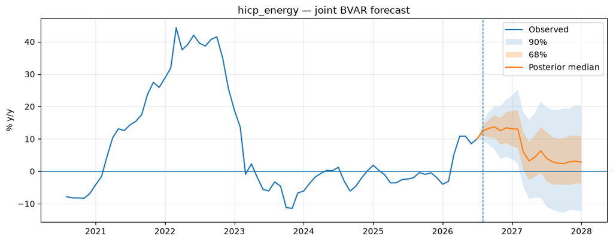

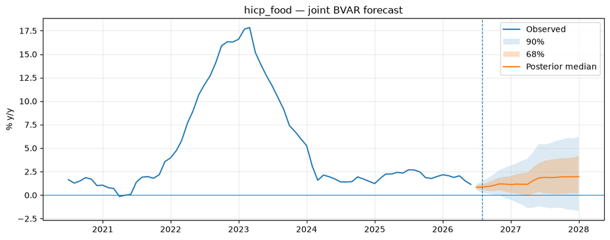

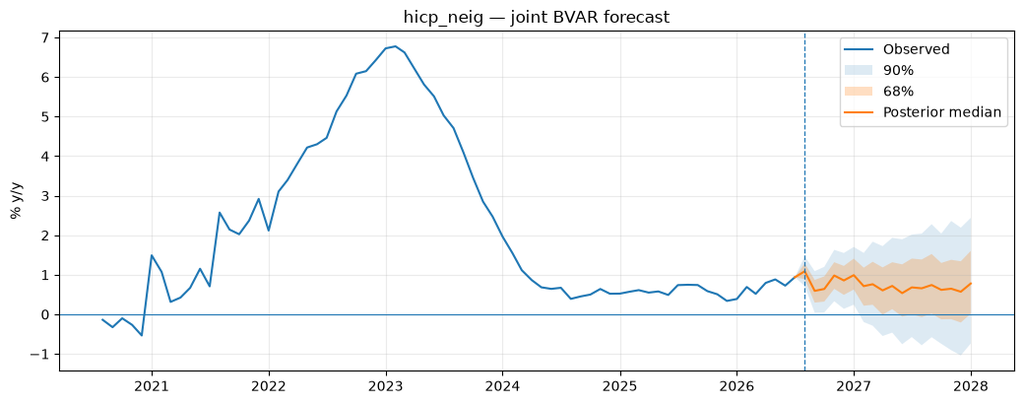

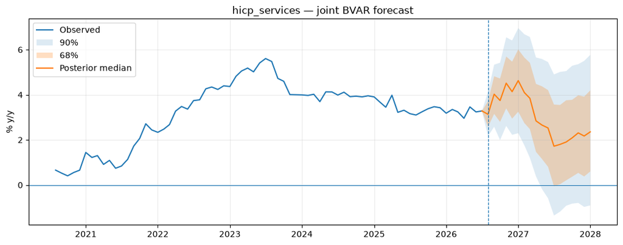

```python
figures = plot_joint_component_forecast_fans(
    component_forecast,
    kind="yoy",
    history=native_levels,
    last_obs=72,
)
for fig in figures.values():
    display(fig)
    plt.close(fig)
```

Each posterior draw contains Energy, Food, NEIG and Services jointly. Therefore draw number (d) is already one coherent four-component BVAR draw; there is no cross-model posterior-pairing problem.

## 11. Draw-by-draw Headline aggregation

```python
headline_forecast = aggregate_headline_draws(
    component_forecast,
    native_levels=native_levels,
    weights=weights,
    official_total=official_total,
    future_weight_policy="carry_forward_latest",
)

print(
    "Max draw-wise contribution additivity error:",
    headline_forecast["headline_drawwise_additivity_max_abs_error"],
)

print("Headline HICP index")
display(headline_forecast_table(headline_forecast, kind="level"))

print("Headline YoY inflation")
display(headline_forecast_table(headline_forecast, kind="yoy"))
```

```
Max draw-wise contribution additivity error: 0.0
Headline HICP index
```

| months_ahead | target_date | q05 | q16 | q50 | q84 | q95 |
| --- | --- | --- | --- | --- | --- | --- |
| 1 | 2026-08-01 | 102.917264 | 103.129642 | 103.467409 | 103.801406 | 104.085696 |
| 3 | 2026-10-01 | 103.012205 | 103.451941 | 104.079440 | 104.737336 | 105.277551 |
| 6 | 2027-01-01 | 102.061794 | 102.810558 | 103.789332 | 104.799780 | 105.621101 |
| 12 | 2027-07-01 | 102.201120 | 103.416620 | 104.825216 | 106.630445 | 107.997409 |
| 18 | 2028-01-01 | 102.214123 | 103.834063 | 105.829332 | 108.033015 | 110.077133 |

```
Headline YoY inflation
```

| months_ahead | target_date | q05 | q16 | q50 | q84 | q95 |
| --- | --- | --- | --- | --- | --- | --- |
| 1 | 2026-08-01 | 2.476615 | 2.688083 | 3.024404 | 3.356971 | 3.640044 |
| 3 | 2026-10-01 | 2.255514 | 2.692020 | 3.314909 | 3.967973 | 4.504219 |
| 6 | 2027-01-01 | 1.990401 | 2.738641 | 3.716731 | 4.726471 | 5.547218 |
| 12 | 2027-07-01 | -0.849742 | 0.297312 | 1.682247 | 3.373801 | 4.719200 |
| 18 | 2028-01-01 | -0.893145 | 0.486937 | 1.964770 | 3.663821 | 4.806904 |

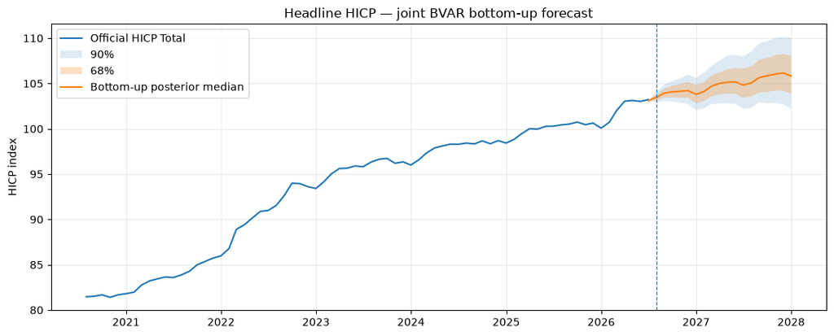

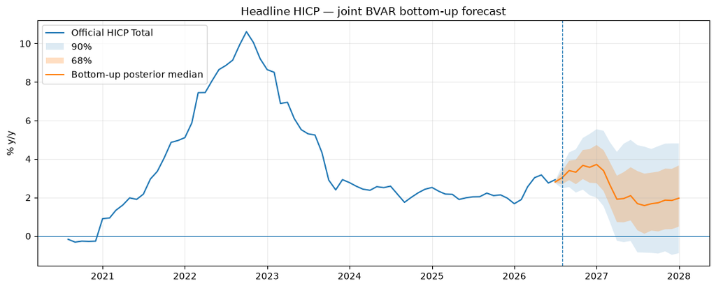

```python
fig = plot_headline_aggregate_forecast(
    headline_forecast,
    official_total,
    kind="level",
)
display(fig)
plt.close(fig)

fig = plot_headline_aggregate_forecast(
    headline_forecast,
    official_total,
    kind="yoy",
)
display(fig)
plt.close(fig)
```

The annual-weight policy is explicit:

- use the published weight vector for year (y) when available;
- if the forecast horizon enters a future year whose weights are not yet published, carry forward the latest complete published vector;
- never backfill a historical weight gap.

The aggregation is performed on component **index paths**, not on weighted inflation rates.

## 12. MCMC and stability diagnostics

MCMC diagnostics

|  | posterior_mean | posterior_sd | ESS | MCSE_mean | MCSE_over_sd |
| --- | --- | --- | --- | --- | --- |
| log likelihood | 5016.19 | 17.99 | 291.71 | 1.05 | 0.06 |
| spectral radius | 1.00 | 1.46 × 10⁻³ | 923.02 | 4.80 × 10⁻⁵ | 0.03 |
| A[state__hicp_food,state__hicp_energy] | -0.01 | 0.01 | 1581.79 | 2.55 × 10⁻⁴ | 0.03 |
| phi[state__hicp_energy] | 0.04 | 0.02 | 50.73 | 2.51 × 10⁻³ | 0.14 |
| p_outlier[state__hicp_energy] | 0.01 | 6.17 × 10⁻³ | 1064.06 | 1.89 × 10⁻⁴ | 0.03 |
| own L1[state__hicp_energy] | 0.37 | 0.05 | 2265.91 | 1.13 × 10⁻³ | 0.02 |
| phi[state__hicp_food] | 0.03 | 0.01 | 54.49 | 1.92 × 10⁻³ | 0.14 |
| p_outlier[state__hicp_food] | 0.01 | 7.46 × 10⁻³ | 309.26 | 4.24 × 10⁻⁴ | 0.06 |
| own L1[state__hicp_food] | 0.36 | 0.06 | 720.51 | 2.26 × 10⁻³ | 0.04 |
| phi[state__hicp_neig] | 0.05 | 0.02 | 37.48 | 3.57 × 10⁻³ | 0.16 |
| p_outlier[state__hicp_neig] | 0.01 | 7.46 × 10⁻³ | 268.30 | 4.55 × 10⁻⁴ | 0.06 |
| own L1[state__hicp_neig] | -0.21 | 0.04 | 880.09 | 1.21 × 10⁻³ | 0.03 |
| phi[state__hicp_services] | 0.01 | 3.72 × 10⁻³ | 99.01 | 3.74 × 10⁻⁴ | 0.10 |
| p_outlier[state__hicp_services] | 7.53 × 10⁻³ | 4.76 × 10⁻³ | 1601.63 | 1.19 × 10⁻⁴ | 0.02 |
| own L1[state__hicp_services] | -0.13 | 0.05 | 1732.74 | 1.18 × 10⁻³ | 0.02 |

|  | value |
| --- | --- |
| retained_draws | 3000.000000 |
| median_spectral_radius | 0.997040 |
| q95_spectral_radius | 0.999322 |
| maximum_spectral_radius | 0.999998 |
| retained_unstable_share | 0.000000 |
| B_total_proposals | 6307.000000 |
| B_unstable_proposals | 307.000000 |
| B_instability_rejection_rate | 0.048676 |

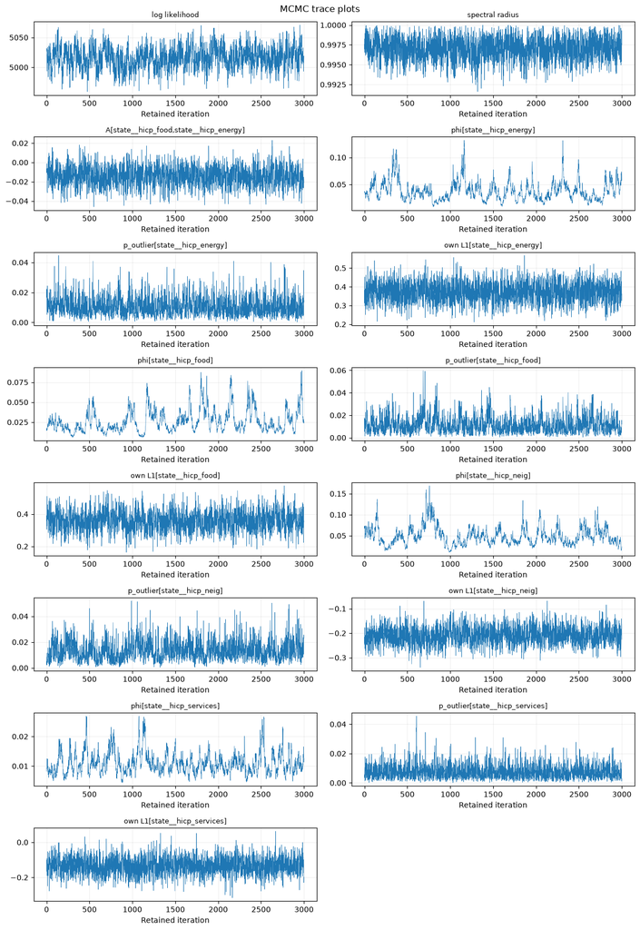

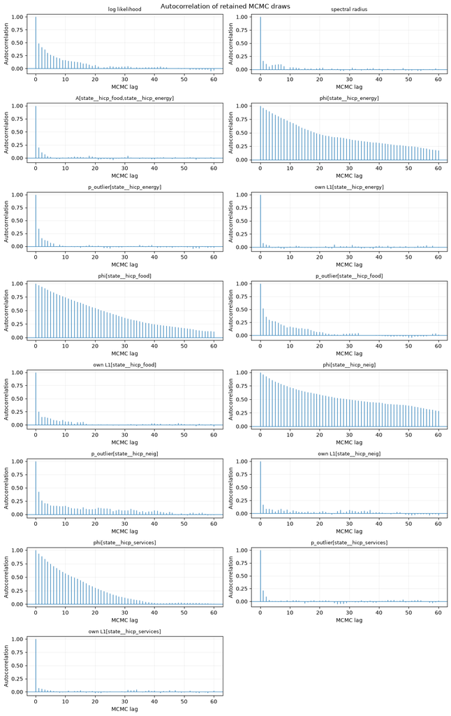

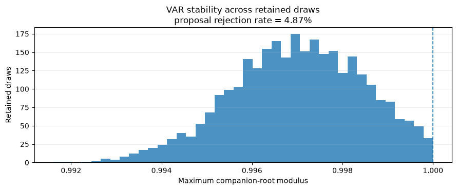

```python
display(style_numeric_table(mcmc_diagnostics(result_12), caption="MCMC diagnostics"))
display(stability_diagnostics(result_12).to_frame("value"))

fig = plot_trace_grid(result_12)
display(fig)
plt.close(fig)

fig = plot_chain_acf_grid(result_12)
display(fig)
plt.close(fig)

fig = plot_spectral_radius(result_12)
display(fig)
plt.close(fig)
```

## 13. Stationarity diagnostics

```python
display(stationarity_tests(state_levels.diff().dropna()))
```

| variable | ADF statistic | ADF p-value | ADF lags | KPSS statistic | KPSS p-value | KPSS lags | observations |
| --- | --- | --- | --- | --- | --- | --- | --- |
| state__hicp_energy | -13.228278 | 9.701157e-25 | 0 | 0.059257 | 0.100000 | 5 | 317 |
| state__hicp_food | -5.042710 | 1.825575e-05 | 11 | 0.198044 | 0.100000 | 9 | 306 |
| state__hicp_neig | -2.709722 | 7.237093e-02 | 11 | 0.206801 | 0.100000 | 42 | 306 |
| state__hicp_services | -1.822450 | 3.693744e-01 | 14 | 0.400065 | 0.077127 | 10 | 303 |

## 14. Posterior predictive checks

Posterior predictive checks

|  | observed | replicated_median | replicated_q05 | replicated_q95 |
| --- | --- | --- | --- | --- |
| state__hicp_energy: mean | 2.90 × 10⁻³ | 1.94 × 10⁻³ | -1.40 × 10⁻³ | 5.87 × 10⁻³ |
| state__hicp_energy: sd | 0.02 | 0.02 | 0.02 | 0.04 |
| state__hicp_energy: maximum_absolute | 0.11 | 0.12 | 0.06 | 0.47 |
| state__hicp_food: mean | 2.12 × 10⁻³ | 1.56 × 10⁻³ | 1.97 × 10⁻⁴ | 2.98 × 10⁻³ |
| state__hicp_food: sd | 3.83 × 10⁻³ | 3.82 × 10⁻³ | 3.18 × 10⁻³ | 7.39 × 10⁻³ |
| state__hicp_food: maximum_absolute | 0.02 | 0.02 | 0.01 | 0.09 |
| state__hicp_neig: mean | 8.06 × 10⁻⁴ | 5.07 × 10⁻⁴ | 8.58 × 10⁻⁵ | 9.34 × 10⁻⁴ |
| state__hicp_neig: sd | 0.02 | 9.38 × 10⁻³ | 6.05 × 10⁻³ | 0.02 |
| state__hicp_neig: maximum_absolute | 0.04 | 0.03 | 0.02 | 0.08 |
| state__hicp_services: mean | 1.85 × 10⁻³ | 1.78 × 10⁻³ | 1.25 × 10⁻³ | 2.24 × 10⁻³ |
| state__hicp_services: sd | 5.42 × 10⁻³ | 4.87 × 10⁻³ | 4.22 × 10⁻³ | 6.80 × 10⁻³ |
| state__hicp_services: maximum_absolute | 0.01 | 0.02 | 0.01 | 0.07 |

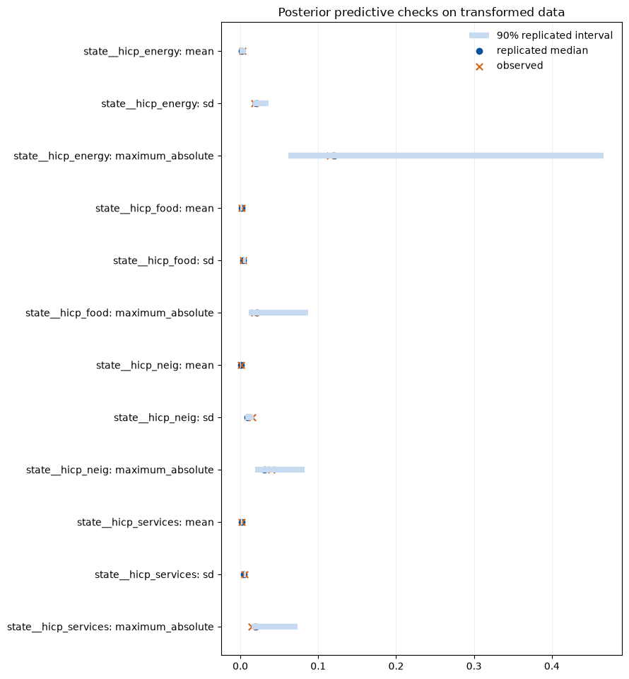

```python
ppc_summary, ppc_draws = posterior_predictive_statistics(
    result_12,
    n_draws=min(300, result_12["n_draws"]),
    seed=321,
)

display(style_numeric_table(ppc_summary, caption="Posterior predictive checks"))

fig = plot_posterior_predictive_check(ppc_summary)
display(fig)
plt.close(fig)
```

## 15. Only lag sensitivity: dense BVAR(6) versus dense BVAR(12)

No automatic lag-selection exercise is performed.

The sole robustness comparison is:

```
dense BVAR(12) — canonical baseline
vs
dense BVAR(6)  — sensitivity
```

The production baseline remains BVAR(12) unless the shorter model reveals a material stability or forecasting problem. A formal forecast-performance comparison should later use the same pseudo-out-of-sample evaluation window for both models.

```python
if RUN_BVAR6_SENSITIVITY:
    result_6 = run_headline_joint_bvar(
        native_levels,
        vintage=VINTAGE_USED,
        p=SENSITIVITY_P,
        prior_config=PRIOR_CONFIG,
        sampler_config=SAMPLER_CONFIG,
        code_version="headline-joint-bvar6-sensitivity-v1",
    )

    comparison = lag_comparison_table(
        {
            6: result_6,
            12: result_12,
        }
    )
    display(comparison)

    forecast_6 = forecast_headline_joint_bvar(
        result_6,
        native_levels=native_levels,
        H=FORECAST_HORIZON,
        n_draws=min(FORECAST_DRAWS, result_6["n_draws"]),
        simulate_future_outliers=True,
        seed=2026,
    )
    headline_forecast_6 = aggregate_headline_draws(
        forecast_6,
        native_levels=native_levels,
        weights=weights,
        official_total=official_total,
    )

    print("BVAR(6) Headline YoY")
    display(headline_forecast_table(headline_forecast_6, kind="yoy"))
else:
    print(
        "BVAR(6) sensitivity disabled. Set RUN_BVAR6_SENSITIVITY=True "
        "only after the canonical BVAR(12) run is validated."
    )
```

[output not shown]

## 16. Save canonical run to the shared registry

```python
if SAVE_RESULTS:
    if save_energy_bvar_result is None:
        raise RuntimeError("energy_bvar_io.save_energy_bvar_result is unavailable.")
    saved = save_energy_bvar_result(result_12, PROJECT_ROOT / "results")
    print("Saved canonical BVAR(12) run to:", saved["directory"])
else:
    print("SAVE_RESULTS=False — canonical run is not promoted to the registry.")
```

```
SAVE_RESULTS=False — canonical run is not promoted to the registry.
```

## Current production contract

```
Excel / Haver / Eurostat
        │
        ├─ HICP Energy
        ├─ HICP Food      (H023HA1@EUDATA)
        ├─ HICP NEIG
        └─ HICP Services
                ↓
       headline_joint_monthly.csv
                ↓
        all four → log state
                ↓
        dense joint BVAR(12)
        Minnesota + SV + outliers + DK
                ↓
      joint posterior component paths
                ↓
     annual HICP component weights
        Food weight = PF + UF
                ↓
       December-rebased chain linking
                ↓
          Headline HICP posterior
                ↓
              dashboard
```

Deferred decomposition models remain separate:

```
notebooks/decomposition/
    11 Unprocessed Food
    12 Processed Food
    13 NEIG
    14 Services
```

They are not required by the current joint Headline production pipeline.